# DCC Inference Demo

tsbs package

2026-01-13

## Overview

This demo walks through DCC(1,1) parameter inference using the tsbs package. We’ll simulate data, estimate parameters, and compare different inference methods.

**Key takeaway**: Hessian-based standard errors severely underestimate uncertainty for beta in high-persistence DCC models. Use bootstrap or profile likelihood instead.

```r
library(tsbs)
```

## Step 1: Simulate DCC Data

We generate bivariate data from a true DCC(1,1) process with known parameters.

```r
## True parameters
alpha_true <- 0.05
beta_true <- 0.90
persistence_true <- alpha_true + beta_true

## Simulation settings
set.seed(42)
n <- 1000  # Number of observations
k <- 2     # Number of series

## Unconditional correlation matrix
Qbar_true <- matrix(c(1.0, 0.5,
                      0.5, 1.0), nrow = 2)

## Initialize storage
z <- matrix(0, n, k)
Q <- array(0, dim = c(k, k, n))
R <- array(0, dim = c(k, k, n))

## Initial values
Q[,,1] <- Qbar_true
R[,,1] <- Qbar_true

## First observation
L1 <- chol(Qbar_true)
z[1, ] <- as.vector(t(L1) %*% rnorm(k))

## Simulate DCC process
for (t in 2:n) {
  ## Update Q using lagged z
  z_lag <- z[t-1, , drop = FALSE]
  Q[,,t] <- (1 - alpha_true - beta_true) * Qbar_true +
            alpha_true * (t(z_lag) %*% z_lag) +
            beta_true * Q[,,t-1]

  ## Normalize to correlation matrix
  d_t <- sqrt(diag(Q[,,t]))
  D_inv <- diag(1 / d_t, k)
  R[,,t] <- D_inv %*% Q[,,t] %*% D_inv

  ## Ensure valid correlation matrix
  R_t <- (R[,,t] + t(R[,,t])) / 2
  diag(R_t) <- 1

  ## Generate correlated innovations
  L <- chol(R_t)
  z[t, ] <- as.vector(t(L) %*% rnorm(k))
}

## Prepare estimation inputs
std_resid <- z
weights <- rep(1, n)
Qbar <- cor(std_resid)  # Sample correlation as Qbar estimate
```

```
#> True parameters:
#>   alpha = 0.05
#>   beta  = 0.9
#>   persistence = 0.95
#>
#> Simulation complete: 1000 observations generated
#> Sample correlation:
#>       [,1]  [,2]
#> [1,] 1.000 0.463
#> [2,] 0.463 1.000
```

## Step 2: Visualize the Dynamic Correlations

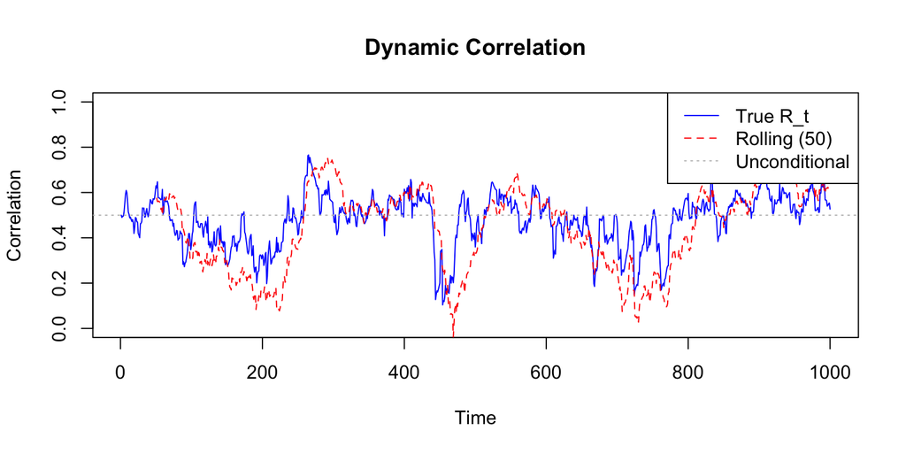

```r
## Compute rolling correlation for visualization
window <- 50
rolling_cor <- sapply((window+1):n, function(t) {
  cor(std_resid[(t-window):t, 1], std_resid[(t-window):t, 2])
})

## True time-varying correlation
true_cor <- sapply(1:n, function(t) R[1, 2, t])

plot(1:n, true_cor, type = "l", col = "blue",
     ylim = c(0, 1), xlab = "Time", ylab = "Correlation",
     main = "Dynamic Correlation")
lines((window+1):n, rolling_cor, col = "red", lty = 2)
abline(h = Qbar_true[1,2], col = "gray", lty = 3)
legend("topright",
       legend = c("True R_t", paste0("Rolling (", window, ")"), "Unconditional"),
       col = c("blue", "red", "gray"), lty = c(1, 2, 3))
```

## Step 3: Find MLE

```r
## Optimize the DCC negative log-likelihood
mle_result <- optim(
  par = c(0.05, 0.90),
  fn = dcc11_nll,
  method = "L-BFGS-B",
  lower = c(1e-6, 1e-6),
  upper = c(0.5, 0.999),
  std_resid = std_resid,
  weights = weights,
  Qbar = Qbar,
  distribution = "mvn",
  use_reparam = FALSE
)

alpha_mle <- mle_result$par[1]
beta_mle <- mle_result$par[2]
params_mle <- c(alpha = alpha_mle, beta = beta_mle)
```

```
#> MLE estimates:
#>   alpha = 0.0278 (true: 0.05 )
#>   beta  = 0.9517 (true: 0.9 )
#>   persistence = 0.9795 (true: 0.95 )
#>
#> Negative log-likelihood: -129.97
#> Convergence: Success
```

## Step 4: Hessian-based Inference

The Hessian of the likelihood provides standard errors, but these are known to underestimate uncertainty for beta in high-persistence DCC models.

```r
## Compute Hessian and standard errors using dcc11_standard_errors
se_result <- dcc11_standard_errors(
  params = params_mle,
  std_resid = std_resid,
  weights = weights,
  Qbar = Qbar,
  distribution = "mvn",
  method = "hessian"
)

## Store eigenvalue ratio for later use
eig_ratio <- if (!is.null(se_result$eigenvalues) && length(se_result$eigenvalues) >= 2) {
  se_result$eigenvalues[1] / se_result$eigenvalues[2]
} else {
  NA
}
```

```
#> Hessian-based inference:
#>   SE(alpha) = 0.0103
#>   SE(beta)  = 0.0225
#>
#> Likelihood surface diagnostics:
#>   Eigenvalues: 31348.6 1719.4
#>   Eigenvalue ratio: 18.2
#>   Condition number: 18.2
#>
#>   WARNING: High eigenvalue ratio indicates anisotropic curvature.
#>            Hessian SE for beta may be severely underestimated.
```

### Robust Standard Errors with Edge Case Handling

The `compute_dcc_standard_errors_robust()` function provides a higher-level interface that handles edge cases like boundary estimates and constant correlation.

```r
## Create a result structure like estimate_dcc_parameters_weighted() returns
dcc_result <- list(
  dcc_pars = list(alpha_1 = alpha_mle, beta_1 = beta_mle),
  dist_pars = list(),
  correlation_type = "dynamic"
)

## Compute robust SEs
robust_se <- compute_dcc_standard_errors_robust(
  dcc_result = dcc_result,
  std_resid = std_resid,
  weights = weights,
  Qbar = Qbar,
  distribution = "mvn",
  method = "hessian"
)
```

```
#> Robust SE computation:
#>   Valid: TRUE
#>   Reason: ok
#>   Correlation type: dynamic
#>   SE(alpha) = 0.0103
#>   SE(beta)  = 0.0225
#>   Info eigenvalues: 31348.6 1719.4
```

### Full Estimation Summary

The `dcc11_estimation_summary()` function provides a comprehensive summary including parameter estimates, standard errors, confidence intervals, and diagnostic information.

```r
## Get full estimation summary
summary_result <- dcc11_estimation_summary(
  params = params_mle,
  std_resid = std_resid,
  weights = weights,
  Qbar = Qbar,
  distribution = "mvn",
  use_reparam = FALSE,
  level = 0.95,
  method = "hessian"
)

## Print the summary (uses the print.dcc11_summary method)
print(summary_result)
```

```
#>
#> ===== DCC(1,1) Estimation Summary =====
#>
#> Data:
#>   Observations: 1000
#>   Series: 2
#>   Distribution: MVN
#>
#> Likelihood:
#>   Log-likelihood: 129.9708
#>   AIC: -255.9416
#>   BIC: -246.1261
#>
#> Parameter Estimates (SE method: hessian):
#>   alpha:       0.0278  (SE: 0.0103)
#>   beta:        0.9517  (SE: 0.0225)
#>   persistence: 0.9795
#>
#> 95% Confidence Intervals:
#>       estimate     se  lower  upper
#> alpha   0.0278 0.0103 0.0077 0.0480
#> beta    0.9517 0.0225 0.9075 0.9958
#> attr(,"level")
#> [1] 0.95
#> attr(,"method")
#> [1] "hessian"
#>
#> Information Matrix Diagnostics:
#>   Condition number: 2.11e+01
#>   Eigenvalue ratio: 18.2
#>   WARNING: High eigenvalue ratio - consider bootstrap SE for beta.
```

### Effect of Reparameterization on Standard Errors

The DCC model can be estimated in the original (α, β) space or in an unconstrained (ψ, φ) space. Let’s compare the standard errors.

```r
## Convert MLE to reparameterized space
reparam_mle <- dcc11_to_unconstrained(alpha_mle, beta_mle)
params_reparam <- c(psi = reparam_mle["psi"], phi = reparam_mle["phi"])

## Compute SEs in reparameterized space
se_reparam <- dcc11_standard_errors(
  params = params_reparam,
  std_resid = std_resid,
  weights = weights,
  Qbar = Qbar,
  distribution = "mvn",
  method = "hessian",
  use_reparam = TRUE
)

## Transform SEs back to original space using delta method
se_transformed <- dcc11_transform_se(se_reparam, to_reparam = FALSE)

## Eigenvalue ratio in reparameterized space
eig_ratio_reparam <- if (!is.null(se_reparam$eigenvalues) && length(se_reparam$eigenvalues) >= 2) {
  se_reparam$eigenvalues[1] / se_reparam$eigenvalues[2]
} else {
  NA
}
```

```
#> Reparameterized MLE:
#>   psi = NA
#>   phi = NA
#>
#> Standard errors in (psi, phi) space:
#>   SE(psi) = 0.7643
#>   SE(phi) = 0.3875
#>
#> Transformed SEs (delta method, back to alpha/beta):
#>   SE(alpha) = 0.0102
#>   SE(beta)  = 0.0224
#>
#> Comparison of SE methods:
#>   Direct (alpha, beta):      SE(alpha) = 0.0103 , SE(beta) = 0.0225
#>   Via reparameterization:    SE(alpha) = 0.0102 , SE(beta) = 0.0224
#>
#> Eigenvalue ratio comparison:
#>   Original space:         18.2
#>   Reparameterized space:  6.5
```

## Step 5: Likelihood Surface Visualization

Let’s visualize why the Hessian-based SE for beta is unreliable.

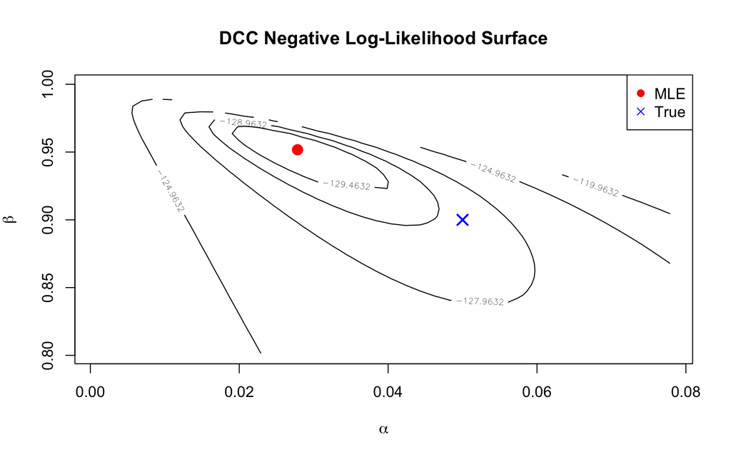

```r
## Create grid around MLE
alpha_grid <- seq(max(0.001, alpha_mle - 0.05),
                  min(0.3, alpha_mle + 0.05),
                  length.out = 40)
beta_grid <- seq(max(0.5, beta_mle - 0.15),
                 min(0.999, beta_mle + 0.05),
                 length.out = 40)

## Compute NLL on grid
nll_surface <- matrix(NA, length(alpha_grid), length(beta_grid))
for (i in seq_along(alpha_grid)) {
  for (j in seq_along(beta_grid)) {
    if (alpha_grid[i] + beta_grid[j] < 0.9999) {
      nll_surface[i, j] <- dcc11_nll(
        params = c(alpha_grid[i], beta_grid[j]),
        std_resid = std_resid,
        weights = weights,
        Qbar = Qbar,
        distribution = "mvn",
        use_reparam = FALSE
      )
    }
  }
}

## Plot contours
nll_min <- min(nll_surface, na.rm = TRUE)
levels <- nll_min + c(0.5, 1, 2, 5, 10, 20, 50)

contour(alpha_grid, beta_grid, nll_surface,
        levels = levels,
        xlab = expression(alpha), ylab = expression(beta),
        main = "DCC Negative Log-Likelihood Surface")
points(alpha_mle, beta_mle, pch = 19, col = "red", cex = 1.5)
points(alpha_true, beta_true, pch = 4, col = "blue", cex = 1.5, lwd = 2)
legend("topright", legend = c("MLE", "True"),
       pch = c(19, 4), col = c("red", "blue"))
```

Notice how the contours are elongated in the beta direction - this is the “flat beta problem” that causes Hessian-based SEs to underestimate uncertainty.

## Step 6: Profile Likelihood

Profile likelihood provides confidence intervals that don’t assume a quadratic likelihood surface. We use `dcc11_profile_ci` for this.

```r
## Compute profile CI for beta
profile_ci_beta <- dcc11_profile_ci(
  params = params_mle,
  std_resid = std_resid,
  weights = weights,
  Qbar = Qbar,
  distribution = "mvn",
  use_reparam = FALSE,
  param_idx = 2,  # beta
  level = 0.95,
  n_grid = 50
)

## Compare to Hessian-based CI
hess_ci_width <- 2 * 1.96 * se_result$se["beta"]

## Also compute profile CI for alpha
profile_ci_alpha <- dcc11_profile_ci(
  params = params_mle,
  std_resid = std_resid,
  weights = weights,
  Qbar = Qbar,
  distribution = "mvn",
  use_reparam = FALSE,
  param_idx = 1,  # alpha
  level = 0.95,
  n_grid = 50
)
```

```
#> 95% Profile Likelihood CI for beta:
#>   [ 0.902 , 0.9682 ]
#>   Width: 0.0662
#>
#> Hessian-based 95% CI width: 0.0883
#> Ratio (Profile/Hessian): 0.7 x
#>
#> 95% Profile Likelihood CI for alpha:
#>   [ 0.0161 , 0.0387 ]
```

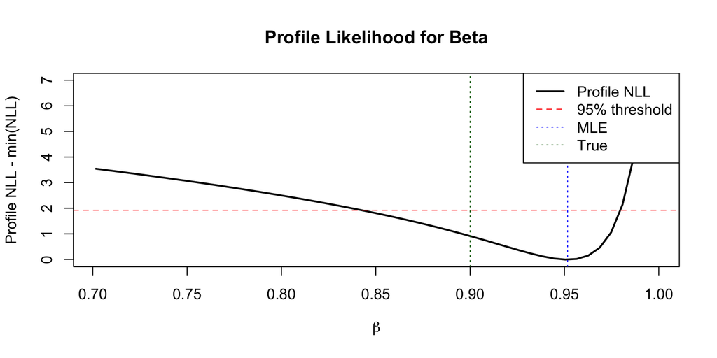

```r
## Visualize profile likelihood for beta
beta_profile_grid <- seq(max(0.5, beta_mle - 0.25),
                         min(0.999, beta_mle + 0.08),
                         length.out = 50)

profile_nll <- sapply(beta_profile_grid, function(b) {
  if (b >= 0.999) return(NA)
  opt <- optim(
    par = alpha_mle,
    fn = function(a) {
      if (a + b >= 0.9999 || a < 0) return(1e10)
      dcc11_nll(c(a, b), std_resid, weights, Qbar, "mvn", FALSE)
    },
    method = "L-BFGS-B",
    lower = 1e-6,
    upper = min(0.5, 0.9999 - b)
  )
  opt$value
})

chi2_95 <- qchisq(0.95, df = 1) / 2

plot(beta_profile_grid, profile_nll - nll_min, type = "l", lwd = 2,
     xlab = expression(beta), ylab = "Profile NLL - min(NLL)",
     main = "Profile Likelihood for Beta")
abline(h = chi2_95, col = "red", lty = 2)
abline(v = beta_mle, col = "blue", lty = 3)
abline(v = beta_true, col = "darkgreen", lty = 3)
legend("topright",
       legend = c("Profile NLL", "95% threshold", "MLE", "True"),
       col = c("black", "red", "blue", "darkgreen"),
       lty = c(1, 2, 3, 3), lwd = c(2, 1, 1, 1))
```

## Step 7: Bootstrap Inference

Bootstrap provides reliable standard errors by resampling the data.

```r
## Residual bootstrap setup
set.seed(123)
n_boot <- 200

boot_estimates <- matrix(NA, n_boot, 2)
colnames(boot_estimates) <- c("alpha", "beta")
```

```
#> Running 200 bootstrap replications...
```

```r
pb <- txtProgressBar(min = 0, max = n_boot, style = 3)

for (b in 1:n_boot) {
  ## Resample rows (residual bootstrap)
  idx <- sample(1:n, n, replace = TRUE)
  boot_resid <- std_resid[idx, ]
  boot_Qbar <- cor(boot_resid)

  ## Re-estimate
  boot_opt <- tryCatch({
    optim(
      par = params_mle,  # Start from MLE
      fn = dcc11_nll,
      method = "L-BFGS-B",
      lower = c(1e-6, 1e-6),
      upper = c(0.5, 0.999),
      std_resid = boot_resid,
      weights = rep(1, n),
      Qbar = boot_Qbar,
      distribution = "mvn",
      use_reparam = FALSE
    )
  }, error = function(e) NULL)

  if (!is.null(boot_opt) && boot_opt$convergence == 0) {
    boot_estimates[b, ] <- boot_opt$par
  }

  setTxtProgressBar(pb, b)
}

close(pb)
```

```r
## Compute bootstrap statistics
valid_boots <- complete.cases(boot_estimates)

boot_se <- apply(boot_estimates[valid_boots, ], 2, sd)
boot_ci <- apply(boot_estimates[valid_boots, ], 2, quantile,
                 probs = c(0.025, 0.975))
```

```
#> Valid bootstrap replications: 197 / 200
#>
#> Bootstrap standard errors:
#>   SE(alpha) = 0.0199
#>   SE(beta)  = 0.3161
#>
#> Bootstrap 95% percentile CIs:
#>   alpha: [ 0 , 0.0669 ]
#>   beta:  [ 0 , 0.9226 ]
```

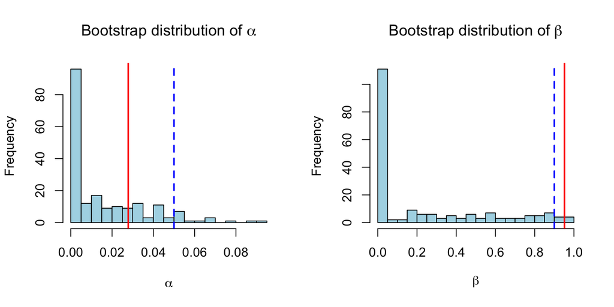

```r
## Visualize bootstrap distribution
par(mfrow = c(1, 2))

hist(boot_estimates[valid_boots, "alpha"], breaks = 30,
     main = expression("Bootstrap distribution of " * alpha),
     xlab = expression(alpha), col = "lightblue")
abline(v = alpha_mle, col = "red", lwd = 2)
abline(v = alpha_true, col = "blue", lwd = 2, lty = 2)

hist(boot_estimates[valid_boots, "beta"], breaks = 30,
     main = expression("Bootstrap distribution of " * beta),
     xlab = expression(beta), col = "lightblue")
abline(v = beta_mle, col = "red", lwd = 2)
abline(v = beta_true, col = "blue", lwd = 2, lty = 2)
```

```r
par(mfrow = c(1, 1))
```

## Step 8: Comparison of Inference Methods

```
#>
#> ========================================
#>        INFERENCE METHOD COMPARISON
#> ========================================
#>  Parameter    MLE True Hessian_SE Bootstrap_SE SE_Ratio
#>      alpha 0.0278 0.05     0.0103       0.0199     0.52
#>       beta 0.9517 0.90     0.0225       0.3161     0.07
#>
#>
#> Key findings:
#> - Hessian SE / Bootstrap SE ratio for alpha: 0.52
#> - Hessian SE / Bootstrap SE ratio for beta: 0.07
#>
#> *** WARNING: Hessian SE for beta is less than half of bootstrap SE ***
#>     This confirms the 'flat beta problem' - use bootstrap for inference.
```

```
#> =============================================
#>          RECOMMENDED INFERENCE RESULTS
#> =============================================
#> Parameter estimates:
#>   alpha = 0.0278 (Hessian SE: 0.0103 )
#>   beta  = 0.9517 (Bootstrap 95% CI: [ 0 , 0.923 ])
#>   persistence = 0.9795
#>
#> Confidence intervals comparison:
#>   Beta - Hessian 95% CI:  [ 0.9075 , 0.9958 ] (width: 0.0883 )
#>   Beta - Profile 95% CI:  [ 0.902 , 0.9682 ] (width: 0.0662 )
#>   Beta - Bootstrap 95% CI:[ 0 , 0.9226 ] (width: 0.9226 )
#>
#> Recommendations:
#> 1. For alpha: Hessian SE is acceptable (ratio ~ 0.5 )
#> 2. For beta: Use bootstrap or profile CI (Hessian underestimates by ~ 14.3 x)
#> 3. The eigenvalue ratio of 18.2 confirms anisotropic curvature
```